# Effects of vaccinations on seropositivity and symptoms prevalences

## Summary

Here we first look at the relationship between vaccination and seroprevalence. Out of the 8 pathogens for which we have serological data, 5 have vaccination. None of these 5 pathogens showed a significant effect of vaccination on the seroprevalence. The analysis was done by correcting for the age of the chicken that tested for serology. Then, for the 8 pathogens, we characterized the trend in seroprevalence as a function of age. 6 did not show any significant trend as a function of age. Seroprevalence was significantly increasing with age for IBV and MG only.

In a second analysis we look at the relationship between vaccination and the prevalence of symptoms of respiratory infections, diarrhoea, CNS infections and sudden death. The prevalences of these 4 symptoms significantly decrease with age. The effect of the 6 vaccines on these four symptoms are somewhat puzzling in the sense that some vaccines do not have any effect on the symptoms that they are supposed to decrease. In some situations, they even increase them instead of decreasing them! Furthermore, other vaccines that are not supposed to have any effect on some symptoms do significantly increase and decrease them. This suggests either that the correspondance between the symptoms and the pathogens that are targeted by the vaccines is way too loose in this system or that there are other factors at play that we didn’t take into account into our analysis (e.g. AMU). The summary of the effects is detailed below:

- **respiratory infections:** NDV and IBD significantly decrease the prevalence of symptoms of respiratory infections as we could expect (although not so much) but HPASI and IBV vaccine on the contrary significanlty increase the prevalence of symptols of respiratory infections. Furthermore, FP and PM which are not supposed to have any effect on the prevalence of respiratory infections significantly increase the prevalence of symptoms of respiratory infections.
- **sudden death:** HPAI significantly decrease the prevalence of sudden death as we could explect but NDV and PM fail in doing so. Surprisingly, FP decreases the prevalence of sudden death whereas IBV, on the contrary, increases it.
- **diarrhoea:** IBD decreases the prevalence of diarrhoea as expected and is the vaccine that does so the most. Surprisingly, IBV and PM also decrease the prevalence of diarrhoea but to a lesser extent than IBD. Still surprinsingly, HPAI increases the prevalence of diarrhoea.
- **CNS infections:** NDV increases the prevalence of CNS a lot whereas it’s supposed to decrease it on the contrary. PM also increases the prevalence of CNS whereas it’s not supposed to have an effect. Surprisingly, IBV decreases the prevalence of CNS whereas it’s not supposed to have any effect on CNS.

## Packages

The required packages:

```r
> required_packages <- c("dplyr", "magrittr", "purrr", "readr", "readxl", "tibble")
> to_install <- setdiff(required_packages, rownames(installed.packages()))
> if (length(to_install)) install.packages(to_install)
```

Laoding the packages for interactive use:

```r
> library(magrittr)
```

## Loading and exploring the serological data

Let’s load and transform the data

```r
> serodata <- readxl::read_excel("SeroData.xlsx") %>%
+   dplyr::mutate_at("Weight.Kg.", as.numeric) %>%
+   dplyr::mutate_at(dplyr::vars(dplyr::starts_with("Sero")), as.logical) %>%
+   dplyr::mutate_at(dplyr::vars(dplyr::ends_with("vaccinated")), as.logical) %>%
+   dplyr::rename(age = `Age(Week)`)
Warning: NAs introduits lors de la conversion automatique
```

Number of observations:

```r
> nrow(serodata)
[1] 267
```

Number of unique flocks:

```r
> length(unique(serodata$FlockID))
[1] 267
```

(i.e. one observation per flock). Number of farms:

```r
> length(unique(serodata$`Farm ID`))
[1] 100
```

Number of flocks per farm:

```r
> serodata %>%
+   dplyr::group_by(`Farm ID`) %>%
+   dplyr::tally() %>%
+   purrr::pluck("n") %>%
+   table()
.
 1  2  3  4  5  6  7  8 11
35 23 14 11 11  2  2  1  1
```

Ages:

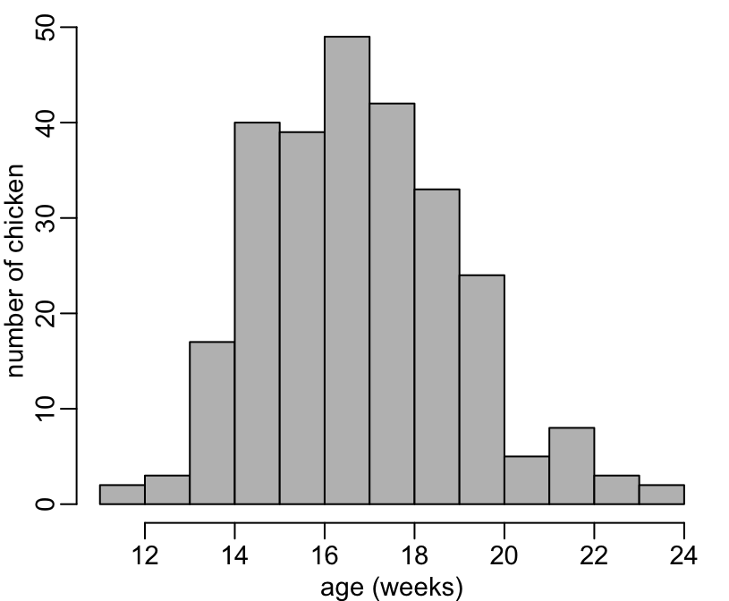

```r
> hist(serodata$age, col = "grey", main = NA, xlab = "age (weeks)", ylab = "number of chicken")
```

Weights:

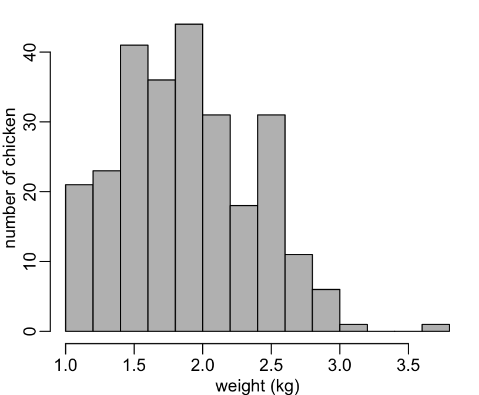

```r
> hist(serodata$Weight.Kg., col = "grey", main = NA, xlab = "weight (kg)", ylab = "number of chicken")
```

No correlation between age and weight:

```r
> summary(lm(Weight.Kg. ~ age, serodata))

Call:
lm(formula = Weight.Kg. ~ age, data = serodata)

Residuals:
     Min       1Q   Median       3Q      Max
-0.96443 -0.37720 -0.02499  0.33004  1.86397

Coefficients:
            Estimate Std. Error t value Pr(>|t|)
(Intercept)  2.12222    0.23855   8.896   <2e-16 ***
age         -0.01105    0.01400  -0.789    0.431
---
Signif. codes:  0 '***' 0.001 '**' 0.01 '*' 0.05 '.' 0.1 ' ' 1

Residual standard error: 0.4943 on 262 degrees of freedom
  (3 observations deleted due to missingness)
Multiple R-squared:  0.002369,  Adjusted R-squared:  -0.001439
F-statistic: 0.6221 on 1 and 262 DF,  p-value: 0.431
```

Visually:

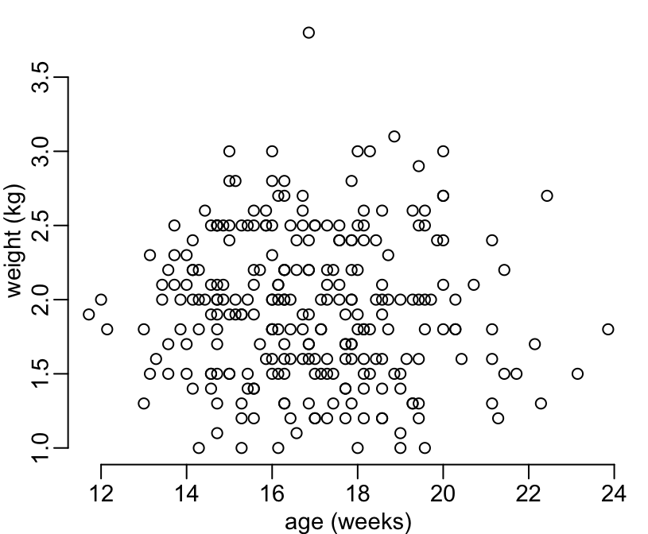

```r
> with(serodata, plot(age, Weight.Kg., xlab = "age (weeks)", ylab = "weight (kg)"))
```

Flock sizes:

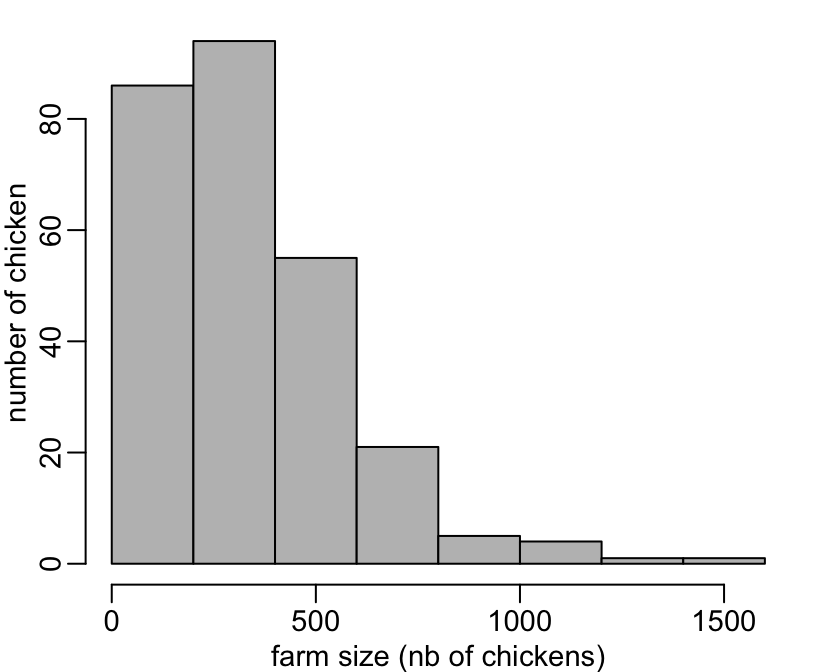

```r
> hist(serodata$Farmsize, col = "grey", xlab = "farm size (nb of chickens)", ylab = "number of chicken")
```

No correlation between farm size and weight:

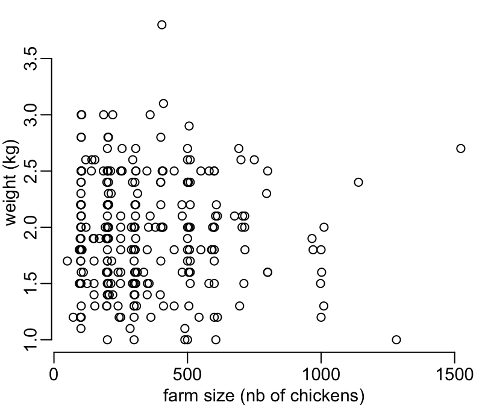

```r
> summary(lm(Weight.Kg. ~ Farmsize, serodata))

Call:
lm(formula = Weight.Kg. ~ Farmsize, data = serodata)

Residuals:
     Min       1Q   Median       3Q      Max
-0.94609 -0.39502 -0.03182  0.35437  1.86825

Coefficients:
              Estimate Std. Error t value Pr(>|t|)
(Intercept)  1.960e+00  5.390e-02  36.365   <2e-16 ***
Farmsize    -7.032e-05  1.274e-04  -0.552    0.582
---
Signif. codes:  0 '***' 0.001 '**' 0.01 '*' 0.05 '.' 0.1 ' ' 1

Residual standard error: 0.4946 on 262 degrees of freedom
  (3 observations deleted due to missingness)
Multiple R-squared:  0.001161,  Adjusted R-squared:  -0.002651
F-statistic: 0.3045 on 1 and 262 DF,  p-value: 0.5815
> with(serodata, plot(Farmsize, Weight.Kg., xlab = "farm size (nb of chickens)", ylab = "weight (kg)"))
```

But age seems to increase with farm size:

```r
> summary(lm(age ~ Farmsize, serodata))

Call:
lm(formula = age ~ Farmsize, data = serodata)

Residuals:
    Min      1Q  Median      3Q     Max
-5.0276 -1.3600 -0.0966  1.3882  6.0929

Coefficients:
             Estimate Std. Error t value Pr(>|t|)
(Intercept) 1.572e+01  2.198e-01  71.500  < 2e-16 ***
Farmsize    3.324e-03  5.187e-04   6.408 6.72e-10 ***
---
Signif. codes:  0 '***' 0.001 '**' 0.01 '*' 0.05 '.' 0.1 ' ' 1

Residual standard error: 2.024 on 265 degrees of freedom
Multiple R-squared:  0.1341,    Adjusted R-squared:  0.1309
F-statistic: 41.06 on 1 and 265 DF,  p-value: 6.72e-10
```

Visually:

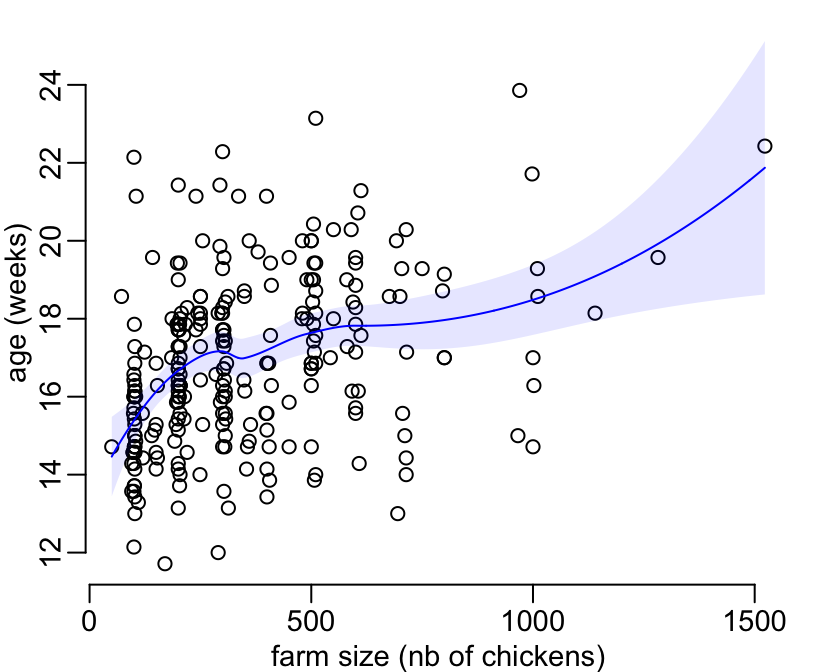

```r
> mod <- loess(age ~ Farmsize, serodata)
> x_val <- with(serodata, seq(min(Farmsize), max(Farmsize), le = 512))
> pred <- predict(mod, data.frame(Farmsize = x_val), se = TRUE)
> y_val <- with(pred, c(fit + qt(.025, Inf) * se.fit, rev(fit + qt(.975, Inf) * se.fit)))
> with(serodata, plot(Farmsize, age, xlab = "farm size (nb of chickens)",
+                     ylab = "age (weeks)",
+                     ylim = c(min(c(age, y_val)), max(c(age, y_val)))))
> polygon(c(x_val, rev(x_val)), y_val, col = adjustcolor("blue", .1), border = NA)
> lines(x_val, pred$fit, col = "blue")
```

## Effect of vaccinations on seroprevalence against pathogens

### Making the data

The following function makes a data frame for a given disease `var`, with 3 columns: `age`, `seropositive` and `vaccinated`:

```r
> make_data <- function(var) {
+   a <- dplyr::select(serodata, age, dplyr::contains(var))
+   sel <- grep("vaccinated", names(a))
+   if (length(sel) > 0) {
+     setNames(a, c("age", "seropositive", "vaccinated"))
+   }
+   dplyr::mutate(a, vaccinated = FALSE) %>%
+     setNames(c("age", "seropositive", "vaccinated"))
+ }
```

The 8 pathogens:

```r
> (vars <- sub("Sero.", "", grep("Sero", names(serodata), value = TRUE)))
[1] "AI"  "CAV" "IBD" "ORT" "NDV" "IBV" "MG"  "PM"
```

Making the data sets for all the pathogens:

```r
> datasets <- setNames(lapply(vars, make_data), vars)
```

Checking which pathogens have vaccination:

```r
> (vaccinated <- datasets %>%
+   sapply(function(x) length(unique(unlist(x[, "vaccinated"]))) > 1))
   AI   CAV   IBD   ORT   NDV   IBV    MG    PM
 TRUE FALSE  TRUE FALSE  TRUE  TRUE FALSE  TRUE
```

### Modeling the data

Methods: for the 5 pathogens for which we have both serological and vaccination data we use a logistic regression the look at the effect of age, vaccination status and interaction on the seroprevalence. Since none of these models show a significant effect of vaccination status, we then use logistic regressions to look at the effects of age on seroprevalence of the 8 pathogens. Only 2 (IBV and MG) show a significant increase of seroprevalence as a function of age with levels close to zero at hatching. Only for these two we perform extrapolation over the whole life time of the chicken. For the 6 other pathogen for which seroprevalence does not depend on age we don’t do interpolation over the age range for which we have data since we have no clue to know whether the oberved level of seroprevalence is reach after a quick increased from zero or was already as such at hatching.

The models:

```r
> models <- lapply(datasets[vaccinated], function(x) glm(seropositive ~ age * vaccinated, binomial, x))
```

The coefficients estimations:

```r
> sapply(models, coef)
                            AI        IBD         NDV        IBV         PM
(Intercept)        -1.13604430  6.8636373  1.78510672 -1.9528695 -10.691360
age                 0.01330976 -0.2694324 -0.12184654  0.1580114   0.422604
vaccinatedTRUE      1.15331113 -6.1369275 -0.80875282 -1.2606290   8.624709
age:vaccinatedTRUE -0.06258336  0.4163490  0.09831679  0.1088592  -0.439410
```

The significativities of age and vaccination on seropositivity against the 5 pathogens against which there is a vaccine:

```r
> models %>%
+   sapply(function(x) anova(x, test = "LRT")$`Pr(>Chi)`) %>%
+   `[`(-1, ) %>%
+   `rownames<-`(c("age", "vaccinated", "age:vaccinated"))
                      AI       IBD       NDV         IBV         PM
age            0.5169695 0.6614363 0.6912190 0.004088135 0.04095817
vaccinated     0.7475972 0.1988441 0.2082602 0.101073655 0.19222618
age:vaccinated 0.7397933 0.2020851 0.7179156 0.507339495 0.07402805
```

The only disease for which vaccination may have a slight effect is PM, but, not only the effect of vaccination would be small, it wouldn’t even be in the right directions…

```r
> predict2 <- function(x) {
+   require(magrittr)
+   linkinv <- family(x)$linkinv
+   ages <- x$data$age
+   age_val <- seq(min(ages), max(ages), le = 512)
+   predict(x, data.frame(age = age_val), se.fit = TRUE) %>%
+     data.frame() %>%
+     dplyr::mutate(lower = linkinv(fit + qt(.025, Inf) * se.fit),
+                   upper = linkinv(fit + qt(.975, Inf) * se.fit),
+                   fit   = linkinv(fit),
+                   age   = age_val) %>%
+     dplyr::select(-residual.scale, -se.fit)
+ }
```

Let’s now focus on the effect of age on seroprevalence for all the pathogens:

```r
> models <- lapply(datasets, function(x) glm(seropositive ~ age, binomial, x))
```

Let’s compute additional data for predictions:

```r
> linkinv <- family(models[[1]])$linkinv
> age_val1 <- seq(min(serodata$age), max(serodata$age), le = 512)
> age_val2 <- seq(0, min(serodata$age), le = 512)
> age_val3 <- range(serodata$age)
> newdata1 <- data.frame(age = age_val1)
> newdata2 <- data.frame(age = age_val2)
> age_pol1 <- c(age_val1, rev(age_val1))
> age_pol2 <- c(age_val2, rev(age_val2))
> age_pol3 <- c(age_val3, rev(age_val3))
```

```r
> predict2 <- function(x, newdata) {
+   require(magrittr)
+   predict(x, newdata, se.fit = TRUE) %>%
+     data.frame() %>%
+     dplyr::mutate(lower = linkinv(fit + qt(.025, Inf) * se.fit),
+                   upper = linkinv(fit + qt(.975, Inf) * se.fit),
+                   fit   = linkinv(fit)) %>%
+     dplyr::select(-residual.scale, -se.fit)
+ }
```

This function does the same as `predict2()` but in case there is no significant relationship with age:

```r
> constant <- function(x) {
+   with(with(x,
+             binom.test(sum(seropositive), length(seropositive))),
+        c(estimate, conf.int))
+ }
```

Let’s look at the significativities of the age effects:

```r
> sapply(models, function(x) coef(summary(x))[2, "Pr(>|z|)"])
         AI         CAV         IBD         ORT         NDV         IBV          MG          PM
0.518343896 0.560203081 0.663876751 0.300271151 0.691107067 0.005384472 0.002566981 0.039601828
```

Age effect on PM after correction for multiple testing does not even remain significant:

```r
> length(models) * sapply(models, function(x) coef(summary(x))[2, "Pr(>|z|)"])
        AI        CAV        IBD        ORT        NDV        IBV         MG         PM
4.14675117 4.48162465 5.31101401 2.40216921 5.52885654 0.04307578 0.02053585 0.31681462
```

Identifying the pathogens for which seroprevalence significantly increases with age:

```r
> (ages_signif <- sapply(models, function(x) coef(summary(x))[2, "Pr(>|z|)"]) < .05 / length(models))
   AI   CAV   IBD   ORT   NDV   IBV    MG    PM
FALSE FALSE FALSE FALSE FALSE  TRUE  TRUE FALSE
```

Computing the models predictions, interpolation for the models where age effect is significant:

```r
> predictions1 <- lapply(models, predict2, newdata1)
```

Extrapolation for the models where age effect is significant:

```r
> predictions2 <- lapply(models, predict2, newdata2)
```

Interpolation for the models where the age effect is not significant:

```r
> predictions3 <- lapply(datasets, constant)
```

This function plots the model predictions in case the age effect is significant:

```r
> plot_pred1 <- function(x, y) {
+   plot(age_val1, x$fit, xlim = c(0, 25), ylim = 0:1, type = "n",
+        xlab = "age (weeks)", ylab = "seroprevalence")
+   polygon(age_pol1, c(x$lower, rev(x$upper)), col = adjustcolor("blue", .2), border = NA)
+   lines(age_val1, x$fit, col = "blue")
+   lines(age_val1, x$lower, col = adjustcolor("blue", .2))
+   lines(age_val1, x$upper, col = adjustcolor("blue", .2))
+   polygon(age_pol2, c(y$lower, rev(y$upper)), 30, 135, NA, col = adjustcolor("blue", .2))
+   lines(age_val2, y$lower, col = adjustcolor("blue", .2))
+   lines(age_val2, y$upper, col = adjustcolor("blue", .2))
+   lines(age_val2, y$fit, col = "blue", lty = 2)
+ }
```

where `x` and `y` are the interpolation and extrapolation predictions respectively. The following function plots the model interpolation predictions in case the age effect is not significant:

```r
> plot_pred2 <- function(x) {
+   plot(age_val3, rep(x[1], 2), xlim = c(0, 25), ylim = 0:1,
+        type = "n", xlab = "age (weeks)", ylab = "seroprevalence")
+   polygon(age_pol3, x[c(2, 2, 3, 3)], col = adjustcolor("blue", .2), border = NA)
+   lines(age_val3, rep(x[1], 2), col = "blue")
+   lines(age_val3, rep(x[2], 2), col = adjustcolor("blue", .2))
+   lines(age_val3, rep(x[3], 2), col = adjustcolor("blue", .2))
+ }
```

Plotting the models’ predictions:

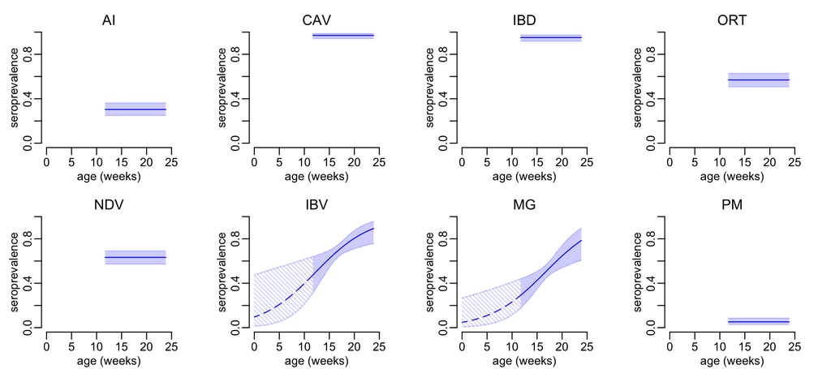

```r
> opar <- par(mfrow = c(2, 4), cex = .83, plt = c(.2, .85, .2, .85))
> for (i in seq_along(vars)) {
+   if (ages_signif[i]) plot_pred1(predictions1[[i]], predictions2[[i]])
+   else plot_pred2(predictions3[[i]])
+   mtext(vars[i], line = 0)
+ }
```

```r
> par(opar)
```

where the areas represent the 95% confidence interval (for extrapolation when hatched and for interpolation when full color). Extrapolations are shown only in cases where age effect is significant. Indeed, when age effect is not significant we have not much clue to know whether the level plateau corresponds to a level that has been reached after an icreased for which we don’t have data or to a level that was constant since hatching.

## Effect of vaccinations on symptoms prevalences

### Making the data

Loading the ViParc data for the week and the symptoms information:

```r
> viparc <- readr::read_csv("https://raw.githubusercontent.com/viparc/clires_data/master/data/viparc.csv",
+                           col_types = paste(c("ciillidddllllll", rep("d", 45)), collapse = "")) %>%
+   dplyr::mutate(FlockID = paste0(farm, flock))
```

Laoding the data on the timings of vaccination:

```r
> fig1 <- readr::read_csv("Figure1.csv", col_types = "cdddddddc") %>%
+   dplyr::select(-CODE) %>%
+   dplyr::mutate_if(is.numeric, as.integer) %>%
+   dplyr::arrange(WEEKNO)
```

The following function splits the information on a given vaccine by flock:

```r
> g <- function(vacc_name) {
+   fig1[, c("FlockID", "WEEKNO", vacc_name)] %>%
+   unique() %>%
+   split(.$FlockID)
+ }
```

The following function recodes, for a data frame containing the vaccination information of a given flock, the vaccination information with `FALSE` for the weeks before vaccination and `TRUE` for the weeks after vaccination:

```r
> f <- function(df) {
+   vacc_names <- grep("vaccinated", names(df))
+   out <- setNames(data.frame(df$FlockID[1], seq_len(max(df$WEEKNO)), 0L, stringsAsFactors = FALSE), names(df))
+   first <- which(df[, vacc_names] > 0)[1]
+   if (is.na(first)) return(out)
+   out[first:nrow(out), vacc_names] <- 1L
+   out
+ }
```

Using the 2 datasets and the 2 functions defined above to generate the dataset for our analysis:

```r
> (vacc_data <- names(fig1) %>%
+   setdiff(c("FlockID", "WEEKNO")) %>%
+   lapply(g) %>%
+   lapply(function(x) dplyr::bind_rows(lapply(x, f))) %>%
+   purrr::reduce(dplyr::left_join, c("FlockID", "WEEKNO")) %>%
+   dplyr::left_join(viparc, "FlockID") %>%
+   dplyr::select(farm, flock, week, respiratory, diarrhoea, cns, sudden_death, ends_with("vaccinated")) %>%
+   dplyr::mutate_at(dplyr::vars(dplyr::ends_with("vaccinated")), as.logical) %>%
+   tibble::as_tibble())
# A tibble: 83,062 x 13
   farm  flock  week respiratory diarrhoea cns   sudden_death Fowl.Pox.vaccin… HPAI.vaccinated NDV.vaccinated IBV.vaccinated
   <chr> <int> <int> <lgl>       <lgl>     <lgl> <lgl>        <lgl>            <lgl>           <lgl>          <lgl>
 1 75-0…     1     1 FALSE       FALSE     FALSE TRUE         FALSE            FALSE           FALSE          FALSE
 2 75-0…     1     2 FALSE       FALSE     FALSE FALSE        FALSE            FALSE           FALSE          FALSE
 3 75-0…     1     3 FALSE       FALSE     FALSE TRUE         FALSE            FALSE           FALSE          FALSE
 4 75-0…     1     4 FALSE       FALSE     FALSE FALSE        FALSE            FALSE           FALSE          FALSE
 5 75-0…     1     5 FALSE       FALSE     FALSE FALSE        FALSE            FALSE           FALSE          FALSE
 6 75-0…     1     6 FALSE       FALSE     FALSE TRUE         FALSE            FALSE           FALSE          FALSE
 7 75-0…     1     7 FALSE       FALSE     FALSE FALSE        FALSE            FALSE           FALSE          FALSE
 8 75-0…     1     8 FALSE       FALSE     FALSE TRUE         FALSE            FALSE           FALSE          FALSE
 9 75-0…     1     9 FALSE       FALSE     FALSE FALSE        FALSE            FALSE           FALSE          FALSE
10 75-0…     1    10 FALSE       FALSE     FALSE FALSE        FALSE            FALSE           FALSE          FALSE
# … with 83,052 more rows, and 2 more variables: IBD.vaccinated <lgl>, PM.vaccinated <lgl>
```

### Modeling the data

Methods: here we combine two data sets for the analysis: The first one gives the timings of vaccination and the second one give the presence of symptoms. The timing information is transformed into a boolean vector that says, for each week of each flock, whether we are before or after vaccination against a particular pathogen. Then, we use logistic regression to model, for each symptom of interest, the effect of being before or after vaccination for all the vaccines, as well age. The results show that, in absence of vaccination, the prevalences of symptoms significantly decrease with age. When accounting for this age effect, as well as correcting for multiple tests, there are a number of vaccination effects that are significant but not always in a way that is expected. This is detailed below and in the summary at the top of this document.

Estimating logistic regressions, one for each of the 4 symptoms:

```r
> vaccine_names <- grep("vaccinated", names(vacc_data), value = TRUE)
> symptoms <- c("respiratory", "sudden_death", "diarrhoea", "cns")
> models <- setNames(lapply(
+   paste(symptoms, "~", paste(c("week", vaccine_names), collapse = "+")),
+   function(x) glm(as.formula(x), binomial, vacc_data)), symptoms)
```

The coefficients of the 4 models:

```r
> (coeff <- sapply(models, coef))
                        respiratory sudden_death   diarrhoea         cns
(Intercept)             -3.26886509 -2.480021669 -1.59367353 -5.76842973
week                    -0.01034532 -0.135563230 -0.13279752 -0.05864383
Fowl.Pox.vaccinatedTRUE  0.71491124 -0.440324531  0.08814244 -0.03104626
HPAI.vaccinatedTRUE      0.17182484 -0.188275723  0.26538141 -0.18044706
NDV.vaccinatedTRUE      -0.41561711  0.069989718 -0.07257318  1.58461512
IBV.vaccinatedTRUE       0.91847669  1.296963086 -0.16813184 -1.25034082
IBD.vaccinatedTRUE      -0.17484649 -0.061754260 -0.34871743  0.20255575
PM.vaccinatedTRUE        0.23386012  0.009836652 -0.20486358  0.86785499
```

The confidence intervals of the coefficients of the 4 models:

```r
> coeff_ci <- lapply(models, confint)
Waiting for profiling to be done...
Waiting for profiling to be done...
Waiting for profiling to be done...
Waiting for profiling to be done...
```

The significativities of the effects for the 4 models, corrected for potential confounding effects:

```r
> models %>%
+   sapply(function(x) car::Anova(x, test = "LR")$`Pr(>Chisq)`) %>%
+   round(4) %>%
+   `rownames<-`(rownames(coeff)[-1])
                        respiratory sudden_death diarrhoea    cns
week                          7e-04       0.0000    0.0000 0.0000
Fowl.Pox.vaccinatedTRUE       0e+00       0.0000    0.0167 0.7144
HPAI.vaccinatedTRUE           0e+00       0.0000    0.0000 0.0490
NDV.vaccinatedTRUE            0e+00       0.4309    0.2668 0.0000
IBV.vaccinatedTRUE            0e+00       0.0000    0.0000 0.0000
IBD.vaccinatedTRUE            4e-04       0.2298    0.0000 0.0546
PM.vaccinatedTRUE             0e+00       0.8802    0.0000 0.0000
```

Correcting for multiple tests:

```r
> models %>%
+   sapply(function(x) car::Anova(x, test = "LR")$`Pr(>Chisq)`) %>%
+   round(4) %>%
+   `rownames<-`(rownames(coeff)[-1]) %>%
+   `*`(length(.))
                        respiratory sudden_death diarrhoea     cns
week                         0.0196       0.0000    0.0000  0.0000
Fowl.Pox.vaccinatedTRUE      0.0000       0.0000    0.4676 20.0032
HPAI.vaccinatedTRUE          0.0000       0.0000    0.0000  1.3720
NDV.vaccinatedTRUE           0.0000      12.0652    7.4704  0.0000
IBV.vaccinatedTRUE           0.0000       0.0000    0.0000  0.0000
IBD.vaccinatedTRUE           0.0112       6.4344    0.0000  1.5288
PM.vaccinatedTRUE            0.0000      24.6456    0.0000  0.0000
```

The link inverse function of the models:

```r
> linkinv <- family(models[[1]])$linkinv
```

Generating some new data for the models predictions:

```r
> newdata <- data.frame(week = seq(min(vacc_data$week), max(vacc_data$week), le = 512),
+                       Fowl.Pox.vaccinated = FALSE, HPAI.vaccinated = FALSE,
+                       NDV.vaccinated = FALSE, IBV.vaccinated = FALSE,
+                       IBD.vaccinated = FALSE, PM.vaccinated = FALSE)
```

The following function takes a model as an input and returns a data frame with 3 columns: predicted value and the lower and upper bounds of the confidence interval of the predictions:

```r
> predict2 <- function(x) {
+   require(magrittr)
+   predict(x, newdata, se.fit = TRUE) %>%
+     data.frame() %>%
+     tibble::as_tibble() %>%
+     dplyr::mutate(lower = linkinv(fit + qt(.025, Inf) * se.fit),
+                   upper = linkinv(fit + qt(.975, Inf) * se.fit),
+                   fit   = linkinv(fit)) %>%
+     dplyr::select(-residual.scale, -se.fit)
+ }
```

Generating the models’ predictions:

```r
> predictions <- lapply(models, predict2)
```

Reformatting the diseases names:

```r
> leg <- names(predictions) %>%
+   sub("_", " ", .) %>%
+   sub("cns", "CNS infections", .) %>%
+   sub("y", "y infections", .)
```

The prevalences of the diseases as functions of age:

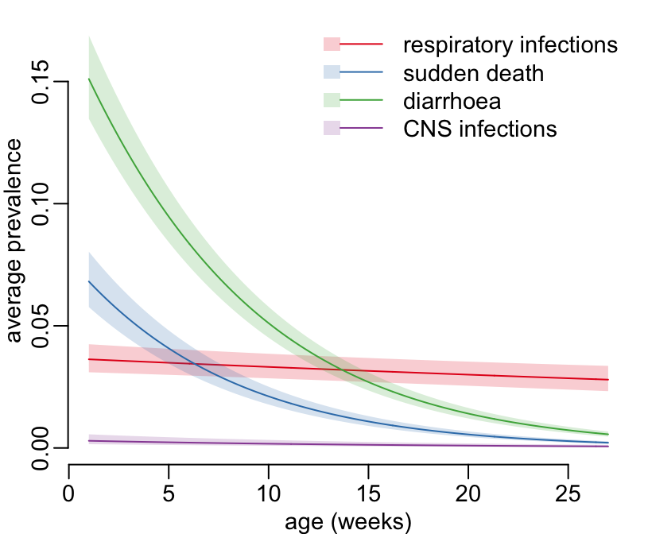

```r
> cols <- c("#e41a1c", "#377eb8", "#4daf4a", "#984ea3")
> fills <- adjustcolor(cols, .2)
> x <- newdata$week
> x_val <- c(x, rev(x))
> plot(x, predictions[[1]]$fit, ylim = c(0,.17), type = "n", xlab = "age (weeks)",
+      ylab = "average prevalence")
> for (i in seq_along(predictions)) {
+   polygon(x_val, c(predictions[[i]]$lower, rev(predictions[[i]]$upper)),
+           col = fills[i], border = NA)
+   lines(x, predictions[[i]]$fit, col = cols[i])
+ }
> legend("topright", legend = leg, fill = fills, col = cols, lty = 1, bty = "n", border = NA)
```

The effects of the vaccines on the prevalences of the diseases:

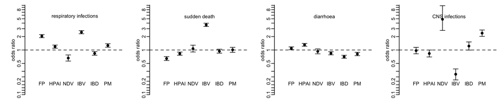

```r
> xs <- 1:6
> ys <- c(1 / seq(0, 10, 1), 1 + seq(0, 10, 1))
> f <- function(x) log2(exp(x))
>
> opar <- par(mfrow = c(1, 4), plt = c(.2, 1, .05, .95))
>
> for (i in seq_along(coeff_ci)) {
+   plot(xs, f(coeff[-(1:2), i]), pch = 19, xlim = c(0, 7), ylim = c(-3.1, 3.1),
+        axes = FALSE, xlab = NA, ylab = "odds ratio")
+   axis(2, log2(ys), ys)
+   text(3.5, 2.5, leg[i])
+ #  text(xs, -2.5, c("NDV", "HPAI", "PM", "IBV", "IBD", "FP"))
+   text(xs, -2.5, c("FP", "HPAI", "NDV", "IBV", "IBD", "PM"))
+   arrows(xs, f(coeff_ci[[i]][-(1:2), 1]), xs, f(coeff_ci[[i]][-(1:2), 2]), .05, 90, 3)
+   abline(h = 0, lty = 2)
+ }
```

```r
> par(opar)
```